# Name :- Vishal Ramashankar Yadav

# Course :- Master in Data Science and Analytics with AI (3 to 5 Batch )

# Contact no :- 9322267388 whatsaap : 7058943711

# Email Adress :- yadavvishal8421@gmail.com

# Project :- Machine Learning Projects

# Topics :- Fast Foods Nutritions Analysis by using Machine Learning

# CONTENT :

1. READING THE DATA
2. ANALYSING THE DATAFRAME COLUMN
3. DATA CLEANING :- EDA process
4. DATA VISUALIZATION
5. DATA SEPERATION AS TEST AND TRAIN DATA
6. HANDELLING OUTLIERS
7. HANDELLING SKEWNESS
   1. Seperating data into numeric and categorical data
8. MACHINE LEARNING STARTED
   1. Split the data into training and testing
   2. Predicting the data using Linear Regression
   3. Predicting the data using Decision Tree
9. Train accuracy is high and Test acc is low
   1. HYPER PARAMETER TUNNING (HPT)
      1. max_depth
      2. min_samples_split
      3. min_samples_leaf
10. Predecting the data using Random Forest
11. CONCLUSION

# FAST FOODS NUTRITIONS ANALYSIS

**INTRODUCTION** :

In todays life we all required a healthy health, for that we should have a knowledge about fast food which one is good for our health or not. so here i going to start my analysis on few famous company brands who serves as a best quality fast foods.

[figure not shown]

#### Food and nutrition are the way that we get fuel, providing energy for our bodies. We need to replace nutrients in our bodies with a new supply every day. Water is an important component of nutrition. Fats, proteins, and carbohydrates are all required.Nutrition is the science that interprets the nutrients and other substances in food in relation to maintenance, growth, reproduction, health and disease of an organism. It includes ingestion, absorption, assimilation, biosynthesis, catabolism and excretion.

#### Knowing and eating mindfully is not only essential for a healthy gut but also for peace of mind. Also,A diet filled with vegetables, fruits and whole grains could help prevent major conditions such as stroke, diabetes and heart disease.More often than not, we like to gorge on our favourite foods which are not exactly the best for our bodies.While it is okay for such binges to occur occasionally, such diets can be extremely harmful if the person does not strike a balance with healthy foods.

# I selected a few fast food famous company for their products nutrition analysis : - KFC, Dominos Pizza, Burger King, Starbucks, McDonalds, Pizza Hut.

[figure not shown]

### Libraries we required for data analysis

[figure not shown]

#### Current working directory will helps to open the csv files without giving a proper location if our csv files present in that folder

#### Here my current working directory is Downloads and my csv file also present at that folder so i dont need to mentioned a proper location eg. C:\Users\admin\Downloads\Nutrition Value Dataset ML Project.csv

```python
#for checking our current working directory in which we working
import os
os.getcwd()
```

```
'C:\\Users\\admin\\Downloads'
```

```python
# Importing required Libraries
import pandas as pd
import numpy as np
from sklearn.impute import SimpleImputer
import seaborn as sns
import matplotlib.pyplot as plt
import warnings
warnings.filterwarnings("ignore")
```

### READING A FAST FOOD DATASET INFORMATION

# 1. READING THE DATA

```python
df=pd.read_csv(r"Nutrition Value Dataset Vishal ML Project.csv")
df
```

|  | Company | Category | Product | Per Serve Size | Energy (kCal) | Carbohydrates (g) | Protein (g) | Fiber (g) | Sugar (g) | Total Fat (g) | Saturated Fat (g) | Trans Fat (g) | Cholesterol (mg) | Sodium (mg) |
| --- | --- | --- | --- | --- | --- | --- | --- | --- | --- | --- | --- | --- | --- | --- |
| 0 | Pizza Hut | All Meals | Corn n Cheese (Personal) | 143.5 g | 432.60 | 65.64 | 17.91 | 3.85 | ? | 10.93 | 5.14 | 0.16 | 16.19 | 499.72 |
| 1 | Pizza Hut | All Meals | Country Feast (Personal) | 178 g | 407.60 | 67.11 | 16.73 | 7.19 | ? | 8.03 | 3.24 | 0.11 | 66.80 | 818.00 |
| 2 | Pizza Hut | All Meals | Double Cheese (Personal) | 143 g | 423.33 | 59.97 | 18.26 | 3.49 | ? | 12.27 | 5.23 | 0.18 | 19.75 | 638.22 |
| 3 | Pizza Hut | All Meals | Double Paneer Supreme (Personal) | 174.5 g | 474.03 | 52.86 | 20.07 | 3.79 | ? | 20.26 | 9.25 | 0.33 | 71.72 | 1128.11 |
| 4 | Pizza Hut | All Meals | Farmer`s Pick (Personal) | 177 g | 408.16 | 53.93 | 19.91 | 2.46 | ? | 12.53 | 4.90 | 0.14 | 48.09 | 942.67 |
| ... | ... | ... | ... | ... | ... | ... | ... | ... | ... | ... | ... | ... | ... | ... |
| 525 | Dominos | All Meals | CHICKEN WINGS | 174 | 352.90 | 24.50 | 35.3 | 5.76 | 10.4 | 12.60 | 4.80 | 0.19 | 308.70 | NaN |
| 526 | Dominos | All Meals | CRISPY CHICKEN STRIPS | 156 | 461.20 | 51.30 | 26.7 | 5.16 | 3.6 | 13.90 | 4.30 | 0.17 | 713.07 | NaN |
| 527 | Dominos | All Meals | ZINGY PARCEL CHICKEN | 210 | 667.50 | 17.30 | 19.2 | 16.92 | 10.6 | 31.30 | 14.10 | 0.56 | 541.49 | NaN |
| 528 | Dominos | All Meals | TACO MEXICANA - CHICKEN | 97 | 322.60 | 34.20 | 9.3 | 5.40 | 3.9 | 16.50 | 4.50 | 0.18 | 564.30 | NaN |
| 529 | Dominos | All Meals | CALZONE POCKETS - CHICKEN | 248 | 582.90 | 101.00 | 18.6 | 5.04 | 12.2 | 11.60 | 4.20 | 0.17 | 1171.60 | NaN |

530 rows × 14 columns

### WE DO ANALYSIS ON BELOWS COMPANY NAMES

```python
df['Company'].unique()
```

```
array(['Pizza Hut', 'Burger King', 'Starbucks', 'McDonalds', 'KFC',
       'Dominos'], dtype=object)
```

# 2. ANALYSING THE DATAFRAME COLUMNS

```python
# for a look of datasets columns names
df.columns
```

```
Index(['Company', 'Category', 'Product', 'Per Serve Size', 'Energy (kCal)',
       'Carbohydrates (g)', 'Protein (g)', 'Fiber (g)', 'Sugar (g)',
       'Total Fat (g)', 'Saturated Fat (g)', 'Trans Fat (g)',
       'Cholesterol (mg)', 'Sodium (mg)'],
      dtype='object')
```

## Dataset has contain a detail of columns as follows :

(a) Company : Name of the Fast Food Company.

(b) Category : The category of the meal.

(c) Product : Name of the Meal.

(d) Per Serve Size : Quantity of the Meal Served.

(e) Energy (kCal) : Energy from the Meal in Kilo Calories.

(f) Carbohydrates (g) : Carbohydrates obtained from the Meal in grams.

(g) Protein (g) : Proteins obtained from the Meal in grams.

(h) Fiber (g) : Fibers obtained from the Meal in grams.

(i) Sugar (g) : Sugars obtained from the Meal in grams.

(j) Total Fat (g) : Total Fats obtained from the Meal in grams.

(k) Saturated Fat (g) : Saturated Fats obtained from the Meal in grams.

(l) Trans Fat (g) : Trans Fat obtained from the Meal in grams.

(m) Cholesterol (mg) : Cholesterol obtained from the Meal in grams.

(n) Sodium (mg) : Sodium obtained from the Meal in grams.

### BASIC INFORMATION OF FAST FOODS DATASET

```python
# for information of columns names dtype and for counts of null objects
df.info()
```

```
<class 'pandas.core.frame.DataFrame'>
RangeIndex: 530 entries, 0 to 529
Data columns (total 14 columns):
 #   Column             Non-Null Count  Dtype
---  ------             --------------  -----
 0   Company            530 non-null    object
 1   Category           530 non-null    object
 2   Product            530 non-null    object
 3   Per Serve Size     530 non-null    object
 4   Energy (kCal)      530 non-null    float64
 5   Carbohydrates (g)  530 non-null    float64
 6   Protein (g)        530 non-null    object
 7   Fiber (g)          530 non-null    float64
 8   Sugar (g)          530 non-null    object
 9   Total Fat (g)      530 non-null    float64
 10  Saturated Fat (g)  530 non-null    float64
 11  Trans Fat (g)      530 non-null    object
 12  Cholesterol (mg)   530 non-null    float64
 13  Sodium (mg)        443 non-null    float64
dtypes: float64(7), object(7)
memory usage: 58.1+ KB
```

```python
# for above 5 rows
df.head()
```

|  | Company | Category | Product | Per Serve Size | Energy (kCal) | Carbohydrates (g) | Protein (g) | Fiber (g) | Sugar (g) | Total Fat (g) | Saturated Fat (g) | Trans Fat (g) | Cholesterol (mg) | Sodium (mg) |
| --- | --- | --- | --- | --- | --- | --- | --- | --- | --- | --- | --- | --- | --- | --- |
| 0 | Pizza Hut | All Meals | Corn n Cheese (Personal) | 143.5 g | 432.60 | 65.64 | 17.91 | 3.85 | ? | 10.93 | 5.14 | 0.16 | 16.19 | 499.72 |
| 1 | Pizza Hut | All Meals | Country Feast (Personal) | 178 g | 407.60 | 67.11 | 16.73 | 7.19 | ? | 8.03 | 3.24 | 0.11 | 66.80 | 818.00 |
| 2 | Pizza Hut | All Meals | Double Cheese (Personal) | 143 g | 423.33 | 59.97 | 18.26 | 3.49 | ? | 12.27 | 5.23 | 0.18 | 19.75 | 638.22 |
| 3 | Pizza Hut | All Meals | Double Paneer Supreme (Personal) | 174.5 g | 474.03 | 52.86 | 20.07 | 3.79 | ? | 20.26 | 9.25 | 0.33 | 71.72 | 1128.11 |
| 4 | Pizza Hut | All Meals | Farmer`s Pick (Personal) | 177 g | 408.16 | 53.93 | 19.91 | 2.46 | ? | 12.53 | 4.90 | 0.14 | 48.09 | 942.67 |

```python
# fr belows 5 rows
df.tail()
```

|  | Company | Category | Product | Per Serve Size | Energy (kCal) | Carbohydrates (g) | Protein (g) | Fiber (g) | Sugar (g) | Total Fat (g) | Saturated Fat (g) | Trans Fat (g) | Cholesterol (mg) | Sodium (mg) |
| --- | --- | --- | --- | --- | --- | --- | --- | --- | --- | --- | --- | --- | --- | --- |
| 525 | Dominos | All Meals | CHICKEN WINGS | 174 | 352.9 | 24.5 | 35.3 | 5.76 | 10.4 | 12.6 | 4.8 | 0.19 | 308.70 | NaN |
| 526 | Dominos | All Meals | CRISPY CHICKEN STRIPS | 156 | 461.2 | 51.3 | 26.7 | 5.16 | 3.6 | 13.9 | 4.3 | 0.17 | 713.07 | NaN |
| 527 | Dominos | All Meals | ZINGY PARCEL CHICKEN | 210 | 667.5 | 17.3 | 19.2 | 16.92 | 10.6 | 31.3 | 14.1 | 0.56 | 541.49 | NaN |
| 528 | Dominos | All Meals | TACO MEXICANA - CHICKEN | 97 | 322.6 | 34.2 | 9.3 | 5.40 | 3.9 | 16.5 | 4.5 | 0.18 | 564.30 | NaN |
| 529 | Dominos | All Meals | CALZONE POCKETS - CHICKEN | 248 | 582.9 | 101.0 | 18.6 | 5.04 | 12.2 | 11.6 | 4.2 | 0.17 | 1171.60 | NaN |

### STATISTICAL INFORMATION OF DATASET¶

```python
# for correlatin of columns
df.corr()
```

|  | Energy (kCal) | Carbohydrates (g) | Fiber (g) | Total Fat (g) | Saturated Fat (g) | Cholesterol (mg) | Sodium (mg) |
| --- | --- | --- | --- | --- | --- | --- | --- |
| Energy (kCal) | 1.000000 | 0.429223 | 0.621665 | 0.797403 | 0.676308 | 0.178290 | 0.112802 |
| Carbohydrates (g) | 0.429223 | 1.000000 | 0.225126 | 0.444378 | 0.429842 | 0.080357 | 0.446827 |
| Fiber (g) | 0.621665 | 0.225126 | 1.000000 | 0.561383 | 0.542190 | 0.227382 | -0.154586 |
| Total Fat (g) | 0.797403 | 0.444378 | 0.561383 | 1.000000 | 0.873274 | 0.334136 | 0.289836 |
| Saturated Fat (g) | 0.676308 | 0.429842 | 0.542190 | 0.873274 | 1.000000 | 0.292933 | 0.190920 |
| Cholesterol (mg) | 0.178290 | 0.080357 | 0.227382 | 0.334136 | 0.292933 | 1.000000 | -0.080553 |
| Sodium (mg) | 0.112802 | 0.446827 | -0.154586 | 0.289836 | 0.190920 | -0.080553 | 1.000000 |

```python
# for stastical viwes of dataset
df.describe()
```

|  | Energy (kCal) | Carbohydrates (g) | Fiber (g) | Total Fat (g) | Saturated Fat (g) | Cholesterol (mg) | Sodium (mg) |
| --- | --- | --- | --- | --- | --- | --- | --- |
| count | 530.000000 | 530.000000 | 530.000000 | 530.000000 | 530.000000 | 530.000000 | 443.000000 |
| mean | 377.304470 | 39.442302 | 4.970340 | 13.228528 | 5.946302 | 118.620434 | 422.431578 |
| std | 338.315722 | 21.196943 | 6.182284 | 10.740934 | 4.844024 | 502.865434 | 471.300077 |
| min | 0.000000 | 0.000000 | 0.000000 | 0.000000 | 0.000000 | 0.000000 | 0.000000 |
| 25% | 180.750000 | 24.227500 | 1.690000 | 5.000000 | 2.500000 | 9.462500 | 1.450000 |
| 50% | 329.645000 | 38.570000 | 3.000000 | 12.600000 | 5.240000 | 30.085000 | 220.000000 |
| 75% | 451.812500 | 54.120000 | 5.997500 | 18.360000 | 8.095000 | 77.535000 | 754.975000 |
| max | 2880.000000 | 137.800000 | 45.000000 | 82.600000 | 33.000000 | 9769.700000 | 2399.490000 |

### Here a minimum values for all columns is showing ZERO, It's mean we need to remove some of outlyier from our data.

# 3. DATA CLEANING :- EDA process

## Finding null/missing values in the data if any.

```python
#Finding null/missing values in the data if any.
df.isnull().sum()
```

```
Company               0
Category              0
Product               0
Per Serve Size        0
Energy (kCal)         0
Carbohydrates (g)     0
Protein (g)           0
Fiber (g)             0
Sugar (g)             0
Total Fat (g)         0
Saturated Fat (g)     0
Trans Fat (g)         0
Cholesterol (mg)      0
Sodium (mg)          87
dtype: int64
```

```python
# for dtypes of each columns
df.info()

print(("*")*125)
print("\t\t\t\t**************ANALYSIS***************\n\n As we see in above info the dtypes of few columns is objects but the data contains in it was floats so we first replace this ? with means of that columns and also the null values we will replace it with the mean values ")
print("\n\n THE MISSED DATA TYPES COLUMNS ARE : \n\n 6   Protein (g)        530 non-null    object \n 8   Sugar (g)          530 non-null    object \n 11  Trans Fat (g)      530 non-null    object")
print(("*")*125)
```

```
<class 'pandas.core.frame.DataFrame'>
RangeIndex: 530 entries, 0 to 529
Data columns (total 14 columns):
 #   Column             Non-Null Count  Dtype
---  ------             --------------  -----
 0   Company            530 non-null    object
 1   Category           530 non-null    object
 2   Product            530 non-null    object
 3   Per Serve Size     530 non-null    object
 4   Energy (kCal)      530 non-null    float64
 5   Carbohydrates (g)  530 non-null    float64
 6   Protein (g)        530 non-null    object
 7   Fiber (g)          530 non-null    float64
 8   Sugar (g)          530 non-null    object
 9   Total Fat (g)      530 non-null    float64
 10  Saturated Fat (g)  530 non-null    float64
 11  Trans Fat (g)      530 non-null    object
 12  Cholesterol (mg)   530 non-null    float64
 13  Sodium (mg)        443 non-null    float64
dtypes: float64(7), object(7)
memory usage: 58.1+ KB
				**************ANALYSIS***************

 As we see in above info the dtypes of few columns is objects but the data contains in it was floats so we first replace this ? with means of that columns and also the null values we will replace it with the mean values


 THE MISSED DATA TYPES COLUMNS ARE :

 6   Protein (g)        530 non-null    object
 8   Sugar (g)          530 non-null    object
 11  Trans Fat (g)      530 non-null    object
```

## To replace '?' with means values in simplest way i will use SimpleImputer from sklearn

#### First we convert '?' to np.nan because simple imputer doesn't recognize it as object

#### bydeafut np.nan is float so we replace '?' with np.nan first then we pass it in simple imputer

```python
df['Protein (g)'].replace('?',np.nan,inplace=True)
df['Sugar (g)'].replace('?',np.nan,inplace=True)
df['Trans Fat (g)'].replace('?',np.nan,inplace=True)
```

```python
from sklearn.impute import SimpleImputer
si = SimpleImputer(missing_values=np.nan, strategy='mean')
```

```python
# now i will pass all columns which contains '?' this symbols
df[['Protein (g)','Sugar (g)','Trans Fat (g)']] = si.fit_transform(df[['Protein (g)','Sugar (g)','Trans Fat (g)']])
```

```python
# for checking its got replace or not
df.info()
print(("*")*125)
print("\t\t\t\t**************ANALYSIS***************\n\n As we see in above info the dtypes of few columns is objects but now they will get replced with their mean values and now their dtypes is float")
print("\n\n THE MISSED DATA TYPES COLUMNS ARE : \n\n 6   Protein (g)        530 non-null    float64 \n 8   Sugar (g)          530 non-null    float64 \n 11  Trans Fat (g)      530 non-null    float64")
print(("*")*125)
```

```
<class 'pandas.core.frame.DataFrame'>
RangeIndex: 530 entries, 0 to 529
Data columns (total 14 columns):
 #   Column             Non-Null Count  Dtype
---  ------             --------------  -----
 0   Company            530 non-null    object
 1   Category           530 non-null    object
 2   Product            530 non-null    object
 3   Per Serve Size     530 non-null    object
 4   Energy (kCal)      530 non-null    float64
 5   Carbohydrates (g)  530 non-null    float64
 6   Protein (g)        530 non-null    float64
 7   Fiber (g)          530 non-null    float64
 8   Sugar (g)          530 non-null    float64
 9   Total Fat (g)      530 non-null    float64
 10  Saturated Fat (g)  530 non-null    float64
 11  Trans Fat (g)      530 non-null    float64
 12  Cholesterol (mg)   530 non-null    float64
 13  Sodium (mg)        443 non-null    float64
dtypes: float64(10), object(4)
memory usage: 58.1+ KB
				**************ANALYSIS***************

 As we see in above info the dtypes of few columns is objects but now they will get replced with their mean values and now their dtypes is float


 THE MISSED DATA TYPES COLUMNS ARE :

 6   Protein (g)        530 non-null    float64
 8   Sugar (g)          530 non-null    float64
 11  Trans Fat (g)      530 non-null    float64
```

### Sodim columns have 87 null values so let replace it with a mean value of that columns

```python
df["Sodium (mg)"]=df["Sodium (mg)"].fillna(df["Sodium (mg)"].mean())
```

```python
# Lets check again null/missing values in the data if any.
df.isnull().sum()
```

```
Company              0
Category             0
Product              0
Per Serve Size       0
Energy (kCal)        0
Carbohydrates (g)    0
Protein (g)          0
Fiber (g)            0
Sugar (g)            0
Total Fat (g)        0
Saturated Fat (g)    0
Trans Fat (g)        0
Cholesterol (mg)     0
Sodium (mg)          0
dtype: int64
```

# 4. DATA VISUALIZATION

### UNDERSTANDING THE DATA BY GRAPHS

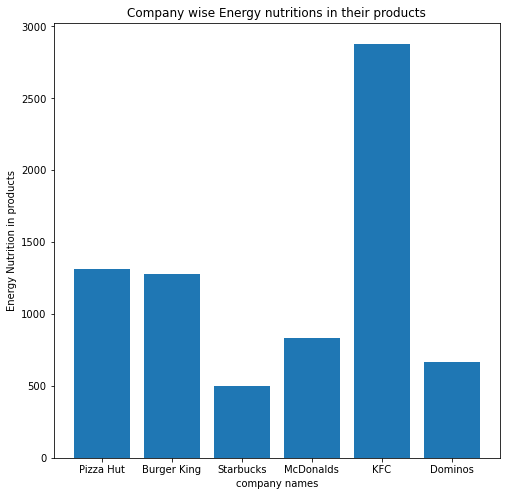

```
				**************ANALYSIS***************

 As we can see in the above graph the KFC products have many Energy Nutrion in their products as compare to other companys products
```

```python
plt.figure(figsize=(8,8))
plt.bar(df['Company'], df['Energy (kCal)'])
plt.xlabel('company names')
plt.ylabel('Energy Nutrition in products')
plt.title('Company wise Energy nutritions in their products')
plt.show()

print(("*")*125)
print("\t\t\t\t**************ANALYSIS***************\n\n As we can see in the above graph the KFC products have many Energy Nutrion in their products as compare to other companys products ")
print(("*")*125)
```

```
Pizza Hut      144
McDonalds      140
Dominos         87
KFC             72
Starbucks       46
Burger King     41
Name: Company, dtype: int64
```

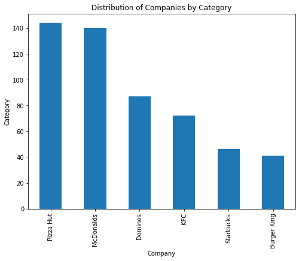

[output not shown]

```python
Company_counts = df['Company'].value_counts()
print(df['Company'].value_counts())

plt.figure(figsize=(8, 6))
Company_counts.plot(kind='bar')
plt.title('Distribution of Companies by Category')
plt.xlabel('Company')
plt.ylabel('Category')
plt.xticks(rotation=90)
plt.show()

print(("*")*125)
print("\t\t\t\t**************ANALYSIS***************\n\nThe bar plot represents that no. of Categories Company wise. Also Observing that Pizza hut has more categories of foods and after that MacDonald, Dominos, KFC, etc.")
print(("*")*125)
```

### Distribution of companys in fast foods productions of sales pie chart

```
				**************ANALYSIS***************

Piechart will shows the Company distribution in percentage wise that captures the hole fast foods markets
```

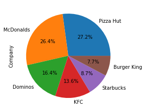

```python
# pie plot of Company Distribution in hole fast foods
df["Company"].value_counts().plot(kind="pie",autopct="%1.1f%%")
print(("*")*125)
print("\t\t\t\t**************ANALYSIS***************\n\nPiechart will shows the Company distribution in percentage wise that captures the hole fast foods markets ")
print(("*")*125)
```

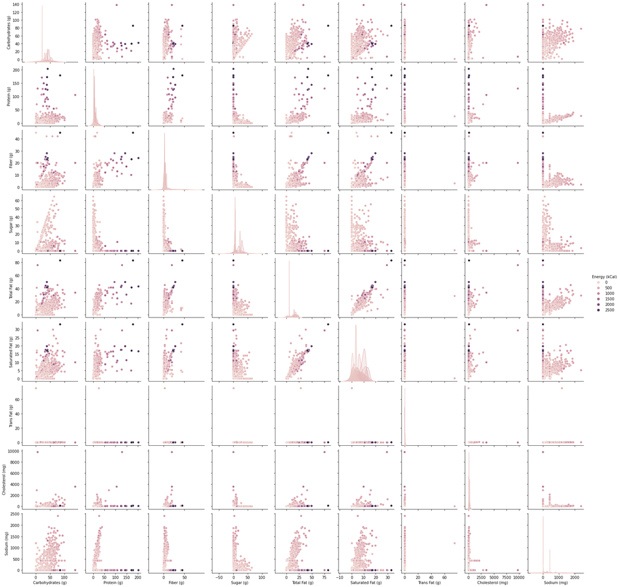

```python
# pair plot will plots a graph to visualize the data properly
sns.pairplot(df[['Energy (kCal)', 'Carbohydrates (g)', 'Protein (g)', 'Fiber (g)', 'Sugar (g)', 'Total Fat (g)', 'Saturated Fat (g)', 'Trans Fat (g)', 'Cholesterol (mg)','Sodium (mg)']], hue='Energy (kCal)')
plt.show()
```

```python
df.info()
```

```
<class 'pandas.core.frame.DataFrame'>
RangeIndex: 530 entries, 0 to 529
Data columns (total 14 columns):
 #   Column             Non-Null Count  Dtype
---  ------             --------------  -----
 0   Company            530 non-null    object
 1   Category           530 non-null    object
 2   Product            530 non-null    object
 3   Per Serve Size     530 non-null    object
 4   Energy (kCal)      530 non-null    float64
 5   Carbohydrates (g)  530 non-null    float64
 6   Protein (g)        530 non-null    float64
 7   Fiber (g)          530 non-null    float64
 8   Sugar (g)          530 non-null    float64
 9   Total Fat (g)      530 non-null    float64
 10  Saturated Fat (g)  530 non-null    float64
 11  Trans Fat (g)      530 non-null    float64
 12  Cholesterol (mg)   530 non-null    float64
 13  Sodium (mg)        530 non-null    float64
dtypes: float64(10), object(4)
memory usage: 58.1+ KB
```

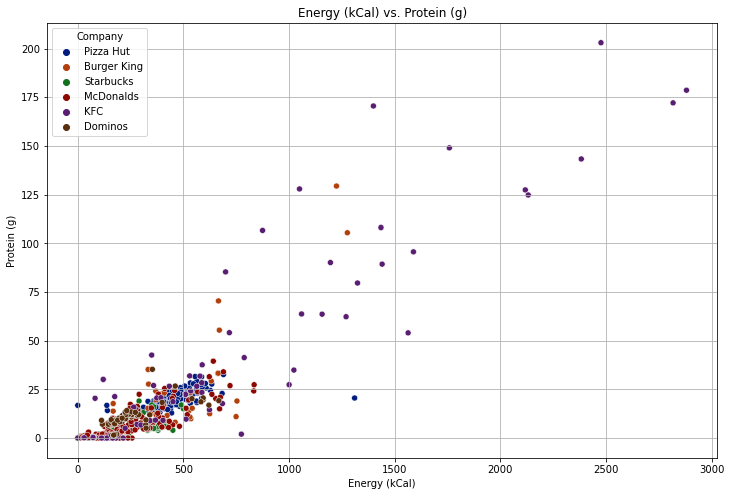

```
				**************ANALYSIS***************

This is representing the Positive correlation between the Energy and Proteins of the products. here, observe that when Amount of Protein are increases then its Energy also increases.
```

```python
plt.figure(figsize=(12, 8))
# for seperation of data representation of data by Company i will use hue from seaborn
sns.scatterplot(data=df,x='Energy (kCal)',y='Protein (g)',hue='Company',palette='dark')
plt.title('Energy (kCal) vs. Protein (g)')
plt.xlabel('Energy (kCal)')
plt.ylabel('Protein (g)')
plt.grid()
plt.show()

print(("*")*125)
print("\t\t\t\t**************ANALYSIS***************\n\nThis is representing the Positive correlation between the Energy and Proteins of the products. here, observe that when Amount of Protein are increases then its Energy also increases.")
print(("*")*125)
```